# New paper markdown file

Gaspar Jekely

Living Systems Institute, University of Exeter, Stocker road, Exeter, EX4 4QD, UK

## Introduction

You can add references either by referring to their id in the .bib file e.g., (Marinković et al., 2019), or by switching to the visual editor (Cogwheel in the .Rmd menu -> Use Visual Editor).

In the visual editor mode, go to ‘Insert’ -> @ Citation

You can select a Zotero library, PubMed, CrossRef etc. and insert the citations.

The references are stored in text/references.bib (defined in the Yaml header). This file will be automatically updated when you insert a new reference.

In this documents, references will be formatted in the style of eLife. This is defined in the Yaml header under: csl: elife.csl.

If you would like to use a different format, download the .csl file (e.g., from the Zotero style repository https://www.zotero.org/styles), save it in the /text folder of the project and change the Yaml to csl: your_favourite_journal.csl.

## Results

Inserting Figures

You can add your figures into the rendered document (to define the path, go up one dir from /text and go into /figures):

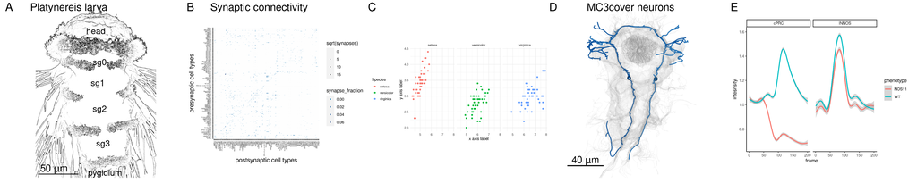

Figure 1

Insert a table with the simple knitr::kable table generator:

| Sepal.Length | Sepal.Width | Petal.Length | Petal.Width | Species |
| --- | --- | --- | --- | --- |
| 5.1 | 3.5 | 1.4 | 0.2 | setosa |
| 4.9 | 3.0 | 1.4 | 0.2 | setosa |
| 4.7 | 3.2 | 1.3 | 0.2 | setosa |
| 4.6 | 3.1 | 1.5 | 0.2 | setosa |
| 5.0 | 3.6 | 1.4 | 0.2 | setosa |
| 5.4 | 3.9 | 1.7 | 0.4 | setosa |

Equations can also be inserted, Insert -> Display Math:

$$\bar{X} = \frac{\sum_{i=1}^{n} x_{i}}{n}$$

## References

Marinković M, Berger J, Jékely G. 2019. Neuronal coordination of motile cilia in locomotion and feeding. *Philosophical Transactions of the Royal Society B: Biological Sciences* **375**:20190165. doi:10.1098/rstb.2019.0165

Ozpolat BD, Randel N, Williams EA, Bezares-Calderón LA, Andreatta G, Balavoine G, Bertucci PY, Ferrier DEK, Gambi MC, Gazave E, Handberg-Thorsager M, Hardege J, Hird C, Hsieh Y-W, Hui J, Mutemi KN, Schneider SQ, Simakov O, Vergara HM, Vervoort M, Jékely G, Tessmar-Raible K, Raible F, Arendt D. 2021. The Nereid on the rise: Platynereis as a model system. *Zenodo*. doi:10.5281/ZENODO.4907400